# Chloé RICHARD

## Data Challenge MDI343 | Supervised Anomaly Detection

### Ms Big Data Télécom Paris x VALÉO

#### Mars 2021

# Introduction

Les données ont été fournies par Valeo, l'un des plus grands équipementiers de France. Il concerne la tâche de détection supervisée des anomalies sur une ligne de production. Pour chacun des articles produits, un ensemble de propriétés est mesuré, et une procédure de test vérifie que l'article est conforme. Toutes les observations sont donc étiquetées comme normales ou défectueuses, les anomalies étant rares. On parle alors de classification supervisée binaire avec deux classes fortement déséquilibrées ou encore de classification supervisée de rares évènements.

L'objectif de ce challenge est de construire un modèle de détection d'anomalies, qui pour chaque nouvelle observation permet de définir un score d'anomalie. Plus le score est élevé, plus une observation a de chance d'être anormale.

Sommaire

1. Chargement des packages
2. Analyse exploratoire des données
3. Feature engineering
4. Choix des métriques
5. Création & entraînement des modèles a. Modèles classiques b. Modèles de Gradient Boosting
6. Résultats
7. Pour aller plus loin
8. Source

# 1. Chargement des packages

```python
# standards
import pandas as pd
import numpy as np
import warnings


# visualisation
import matplotlib.pyplot as plt
import seaborn as sns


# preprocessing
from sklearn.preprocessing import StandardScaler


# modèles
from sklearn.model_selection import train_test_split, GridSearchCV
from sklearn.linear_model import LogisticRegression
from sklearn.ensemble import RandomForestClassifier
import xgboost as xgb
from xgboost import XGBClassifier
from pyod.models.xgbod import XGBOD



# résultats
from sklearn.base import BaseEstimator, TransformerMixin
from sklearn.metrics import roc_auc_score, roc_curve, precision_recall_curve, \
                            average_precision_score, recall_score, \
                            precision_score, f1_score, confusion_matrix, log_loss, classification_report
from pyod.utils.data import evaluate_print
from plot_metric.functions import BinaryClassification
from sklearn.metrics import precision_recall_curve, plot_precision_recall_curve
```

# pour ploter la courbe ROC pip install plot_metric # pour utiliser XGBOD pip install pyod

# 2. Analyse exploratoire des données

L’analyse exploratoire permet de dégager les aspects les plus intéressants de la structure d'un ensemble de données. On utilise essentiellement des représentations graphiques afin de mettre en évidence des relations entre les données.

## 2.1. Data Sourcing

C'est le processus qui consiste à trouver et charger les données.

```python
# import des données d'entraînement
xtrain = pd.read_csv("data/valeo_xtrain.csv")
ytrain = pd.read_csv("data/valeo_ytrain.csv")

# import des données de test
xtest = pd.read_csv("data/valeo_xtest.csv")

#check des dimensions
print(f'xtrain.shape : {xtrain.shape}\nytrain.shape : {ytrain.shape}\nxtest.shape : {xtest.shape}\n')

# check des tables
##xtrain.head(5)
#ytrain.head(5)
xtest.head(5)
```

```
xtrain.shape : (27586, 27)
ytrain.shape : (27586, 1)
xtest.shape : (27587, 27)
```

|  | START2_OP020_V_1angle | START2_OP020_V_1torque | START2_OP020_V_2angle | START2_OP020_V_2torque | START2_OP040_Vision_cosseprog | START2_OP050_Vision_paliermodel | START2_OP050_Vision_palierpresencedouille | START2_OP060_Vision_tirantcouleur | START2_OP070_V_1angle | START2_OP070_V_1prog | ... | START2_OP090_SnapRingFinalStroke | START2_OP090_SnapRingMidPointForce | START2_OP090_SnapRingPeakForce | START2_OP090_StartLinePeakForce | START2_OP100_Capuchon_insertionmesure | START2_OP110_Vissage_M8angle | START2_OP110_Vissage_M8prog | START2_OP110_Vissage_M8torque | START2_OP120_RodageI_mesure | START2_OP120_RodageU_mesure |
| --- | --- | --- | --- | --- | --- | --- | --- | --- | --- | --- | --- | --- | --- | --- | --- | --- | --- | --- | --- | --- | --- |
| 0 | 35.1 | 3.78 | 37.4 | 3.77 | 700.0 | 2.0 | 1.0 | 1.0 | 144.1 | 7.0 | ... | 11.58 | 78.73 | 137.70 | 27.91 | 0.41 | 15.0 | 1.0 | 12.14 | 114.68 | 11.97 |
| 1 | 35.2 | 3.75 | 33.2 | 3.75 | 1300.0 | 2.0 | 1.0 | 1.0 | 153.5 | 7.0 | ... | 12.12 | 71.78 | 135.23 | 16.29 | 0.23 | 23.8 | 1.0 | 12.25 | 120.63 | 11.97 |
| 2 | 46.1 | 3.79 | 36.1 | 3.77 | 1100.0 | 2.0 | 1.0 | 1.0 | 131.1 | 7.0 | ... | 11.92 | 67.03 | 161.63 | 20.99 | 0.12 | 16.8 | 1.0 | 12.17 | 142.24 | 11.97 |
| 3 | 35.0 | 3.76 | 43.7 | 3.79 | 1300.0 | 2.0 | 1.0 | 1.0 | 147.1 | 7.0 | ... | 11.93 | 76.06 | 123.96 | 23.47 | 0.23 | 18.5 | 1.0 | 12.19 | 116.94 | 11.97 |
| 4 | 44.9 | 3.76 | 31.9 | 3.79 | 700.0 | 2.0 | 1.0 | 1.0 | 163.1 | 7.0 | ... | 11.59 | 62.30 | 126.82 | 35.31 | 0.41 | 13.5 | 1.0 | 12.18 | 120.41 | 11.97 |

5 rows × 27 columns

```python
# check des taux d'anomalies
print(f'Répartition des classes dans le dataset d\'entrainement xtrain : \n{ytrain["Anomaly"].value_counts() / len(ytrain)}')
```

```
Répartition des classes dans le dataset d'entrainement xtrain :
0    0.974879
1    0.025121
Name: Anomaly, dtype: float64
```

On observe que la classe anormale ne représente que 2.5 % des données d'entraînement. Nous sommes donc dans un problème de classification où les classes ne sont pas représentées de manière égales, elles sont déquilibrées. C'est une situation qui est relativement fréquente dans certaines industries et qui est parfois attendue, on peut penser notamment à la détection de fraudes où la majorité des données représentent des cas de "non-fraude".

Dans notre cas, nous cherchons à prédire si une pièce sera oui ou non anormale. Le déséquilibre qu'il existe entre nos deux classes et le nombre très faible de données anormales vont rendre difficile la phase d'apprentissage par l'algorithme de classification. Il sera en effet biaisé vers la population des données normales et sera par conséquent à l'origine de prédictions moins robustes et fiables, qu'en l'absence de déséquilibre.

Pour améliorer la qualité et les performances de prédiction, nous chercherons à modéliser le problème et à comprendre les données. Une attention particulière sera portée afin d'accroître la séparabilité des classes. Pour ce faire, on réalisera :

- Une analyse exploratoire des données pour améliorer leur compréhension
- Une feature engineering pour générer des variables discriminantes (en limitant le bruit)
- La réduction de la dimensionnalité ?
- Le ré-échantillonnage ?
- L'utilisation de méthodes de cost-sensitive learning
- Le choix d'une métrique adaptée

## 2.2. Data Cleaning

L'étape suivante de l'EDA est le nettoyage des données. C'est une étape fondamentale qui vise à détecter, corriger ou supprimer les irrégularités (doublons, valeurs manquantes, format incorrect, en-tête invalide, outliers) potentiellement présentes dans un jeu de données. Elle permet ainsi d'améliorer la cohérence, la fiabilité et in fine la qualité des prédictions réalisées grâce à ces données.

### 2.2.1. Check Types

Lors de l'analyse des données, il est important de s'assurer que l'on utilise les bons types de données, afin d'éviter l'obtention de résultats inattendus ou des erreurs.

```python
# visualisation du types des features de xtrain
xtrain.info()
```

```
<class 'pandas.core.frame.DataFrame'>
RangeIndex: 27586 entries, 0 to 27585
Data columns (total 27 columns):
 #   Column                                     Non-Null Count  Dtype
---  ------                                     --------------  -----
 0   START2_OP020_V_1angle                      27586 non-null  float64
 1   START2_OP020_V_1torque                     27586 non-null  float64
 2   START2_OP020_V_2angle                      27586 non-null  float64
 3   START2_OP020_V_2torque                     27586 non-null  float64
 4   START2_OP040_Vision_cosseprog              27586 non-null  float64
 5   START2_OP050_Vision_paliermodel            27586 non-null  float64
 6   START2_OP050_Vision_palierpresencedouille  27586 non-null  float64
 7   START2_OP060_Vision_tirantcouleur          27586 non-null  float64
 8   START2_OP070_V_1angle                      27586 non-null  float64
 9   START2_OP070_V_1prog                       27586 non-null  float64
```

[output cut: 19 more lines]

```python
# visualisation du types des features de xtest
xtest.info()
```

```
<class 'pandas.core.frame.DataFrame'>
RangeIndex: 27587 entries, 0 to 27586
Data columns (total 27 columns):
 #   Column                                     Non-Null Count  Dtype
---  ------                                     --------------  -----
 0   START2_OP020_V_1angle                      27587 non-null  float64
 1   START2_OP020_V_1torque                     27587 non-null  float64
 2   START2_OP020_V_2angle                      27587 non-null  float64
 3   START2_OP020_V_2torque                     27587 non-null  float64
 4   START2_OP040_Vision_cosseprog              27587 non-null  float64
 5   START2_OP050_Vision_paliermodel            27587 non-null  float64
 6   START2_OP050_Vision_palierpresencedouille  27587 non-null  float64
 7   START2_OP060_Vision_tirantcouleur          27587 non-null  float64
 8   START2_OP070_V_1angle                      27587 non-null  float64
 9   START2_OP070_V_1prog                       27587 non-null  float64
```

[output cut: 19 more lines]

```python
# visualisation du types des features de ytrain
ytrain.info()
```

```
<class 'pandas.core.frame.DataFrame'>
RangeIndex: 27586 entries, 0 to 27585
Data columns (total 1 columns):
 #   Column   Non-Null Count  Dtype
---  ------   --------------  -----
 0   Anomaly  27586 non-null  int64
dtypes: int64(1)
memory usage: 215.6 KB
```

### 2.2.2. Handles Missing Values

```python
# check des valeurs manquantes xtrain
xtrain.isnull().sum()
```

```
START2_OP020_V_1angle                        0
START2_OP020_V_1torque                       0
START2_OP020_V_2angle                        0
START2_OP020_V_2torque                       0
START2_OP040_Vision_cosseprog                0
START2_OP050_Vision_paliermodel              0
START2_OP050_Vision_palierpresencedouille    0
START2_OP060_Vision_tirantcouleur            0
START2_OP070_V_1angle                        0
START2_OP070_V_1prog                         0
START2_OP070_V_1torque                       0
START2_OP070_V_2angle                        0
START2_OP070_V_2prog                         0
START2_OP070_V_2torque                       0
START2_OP080_Vision_rondelleprog             0
START2_OP090_MaxMidForceLimit                0
START2_OP090_MinMidForceLimit                0
START2_OP090_SnapRingFinalStroke             0
START2_OP090_SnapRingMidPointForce           0
START2_OP090_SnapRingPeakForce               0
START2_OP090_StartLinePeakForce              0
START2_OP100_Capuchon_insertionmesure        0
START2_OP110_Vissage_M8angle                 0
START2_OP110_Vissage_M8prog                  0
START2_OP110_Vissage_M8torque                0
START2_OP120_RodageI_mesure                  0
START2_OP120_RodageU_mesure                  0
dtype: int64
```

```python
# check des valeurs manquantes xtraxtestin
xtest.isnull().sum()
```

```
START2_OP020_V_1angle                        0
START2_OP020_V_1torque                       0
START2_OP020_V_2angle                        0
START2_OP020_V_2torque                       0
START2_OP040_Vision_cosseprog                0
START2_OP050_Vision_paliermodel              0
START2_OP050_Vision_palierpresencedouille    0
START2_OP060_Vision_tirantcouleur            0
START2_OP070_V_1angle                        0
START2_OP070_V_1prog                         0
START2_OP070_V_1torque                       0
START2_OP070_V_2angle                        0
START2_OP070_V_2prog                         0
START2_OP070_V_2torque                       0
START2_OP080_Vision_rondelleprog             0
START2_OP090_MaxMidForceLimit                0
START2_OP090_MinMidForceLimit                0
START2_OP090_SnapRingFinalStroke             0
START2_OP090_SnapRingMidPointForce           0
START2_OP090_SnapRingPeakForce               0
START2_OP090_StartLinePeakForce              0
START2_OP100_Capuchon_insertionmesure        0
START2_OP110_Vissage_M8angle                 0
START2_OP110_Vissage_M8prog                  0
START2_OP110_Vissage_M8torque                0
START2_OP120_RodageI_mesure                  0
START2_OP120_RodageU_mesure                  0
dtype: int64
```

```python
# check des valeurs manquantes ytrain
ytrain.isnull().sum()
```

```
Anomaly    0
dtype: int64
```

Comme on peut le voir, il n'y aucune valeurs manquantes au sein de notre jeu de données.

### 2.2.3. Handles Duplicates

```python
# check des doublons dans xtrain
xtrain.duplicated(keep = False).sum()
```

```
654
```

```python
# check des doublons dans xtest
xtest.duplicated(keep = False).sum()
```

```
706
```

> **Remarque : keep = False** permet de retourner toutes les lignes en double sans exception. En effet, la valeur par défaut d la méthode *duplicated* ne renvoie pas la première occurence de chaque doublon.

On remarque que le nombre de doublon (`654`) est très proche du nombre d'anomalie (`693`) dans le jeu d'apprentissage xtrain. On suppose alors que les doublons sont de potentielles anomalies. On affiche leurs statistiques descriptives afin de vérifier si leur distribution est similaire.

```python
print(f"""Nombre d'anomalies dans xtrain : {ytrain["Anomaly"].sum()}\nNombre de doublons dans xtrain : {xtrain.duplicated(keep = False).sum()}""")
```

```
Nombre d'anomalies dans xtrain : 693
Nombre de doublons dans xtrain : 654
```

```python
# check des stats descriptives des doublons dans xtrain
xtrain.loc[xtrain.duplicated(keep = False)].describe()
```

|  | START2_OP020_V_1angle | START2_OP020_V_1torque | START2_OP020_V_2angle | START2_OP020_V_2torque | START2_OP040_Vision_cosseprog | START2_OP050_Vision_paliermodel | START2_OP050_Vision_palierpresencedouille | START2_OP060_Vision_tirantcouleur | START2_OP070_V_1angle | START2_OP070_V_1prog | ... | START2_OP090_SnapRingFinalStroke | START2_OP090_SnapRingMidPointForce | START2_OP090_SnapRingPeakForce | START2_OP090_StartLinePeakForce | START2_OP100_Capuchon_insertionmesure | START2_OP110_Vissage_M8angle | START2_OP110_Vissage_M8prog | START2_OP110_Vissage_M8torque | START2_OP120_RodageI_mesure | START2_OP120_RodageU_mesure |
| --- | --- | --- | --- | --- | --- | --- | --- | --- | --- | --- | --- | --- | --- | --- | --- | --- | --- | --- | --- | --- | --- |
| count | 654.000000 | 654.000000 | 654.000000 | 654.000000 | 654.000000 | 654.000000 | 654.000000 | 654.000000 | 654.000000 | 654.000000 | ... | 654.000000 | 654.000000 | 654.000000 | 654.000000 | 654.000000 | 654.000000 | 654.000000 | 654.000000 | 654.000000 | 654.000000 |
| mean | 36.225688 | 3.776361 | 39.304893 | 3.777645 | 1008.681957 | 1.785933 | 1.003058 | 1.214067 | 135.565138 | 7.217125 | ... | 11.793639 | 88.731560 | 177.537706 | 27.598226 | 0.299725 | 20.870336 | 1.131498 | 11.853731 | 124.903976 | 11.858930 |
| std | 7.407683 | 0.017965 | 5.863248 | 0.013678 | 445.550804 | 0.410488 | 0.055258 | 0.410488 | 19.994614 | 0.412604 | ... | 0.189920 | 12.543804 | 20.755303 | 8.908525 | 0.125581 | 11.788192 | 0.338203 | 0.888630 | 14.024866 | 0.899132 |
| min | 23.300000 | 3.750000 | 28.000000 | 3.750000 | 3.000000 | 1.000000 | 1.000000 | 1.000000 | 87.400000 | 7.000000 | ... | 11.250000 | 56.710000 | 90.910000 | 10.500000 | 0.120000 | 9.100000 | 1.000000 | 9.500000 | 109.170000 | 3.900000 |
| 25% | 30.300000 | 3.760000 | 34.900000 | 3.770000 | 700.000000 | 2.000000 | 1.000000 | 1.000000 | 122.750000 | 7.000000 | ... | 11.720000 | 81.925000 | 171.360000 | 22.965000 | 0.230000 | 13.600000 | 1.000000 | 12.120000 | 117.012500 | 11.970000 |
| 50% | 34.500000 | 3.780000 | 38.300000 | 3.770000 | 1300.000000 | 2.000000 | 1.000000 | 1.000000 | 139.900000 | 7.000000 | ... | 11.750000 | 88.690000 | 181.920000 | 25.320000 | 0.230000 | 16.200000 | 1.000000 | 12.180000 | 120.630000 | 11.970000 |
| 75% | 40.950000 | 3.790000 | 43.550000 | 3.790000 | 1300.000000 | 2.000000 | 1.000000 | 1.000000 | 149.675000 | 7.000000 | ... | 11.820000 | 94.360000 | 190.807500 | 30.607500 | 0.410000 | 23.350000 | 1.000000 | 12.230000 | 127.757500 | 11.970000 |
| max | 60.000000 | 3.830000 | 55.500000 | 3.820000 | 1500.000000 | 2.000000 | 2.000000 | 2.000000 | 180.500000 | 8.000000 | ... | 12.570000 | 121.790000 | 214.770000 | 74.950000 | 0.600000 | 64.200000 | 2.000000 | 12.410000 | 199.300000 | 11.980000 |

8 rows × 27 columns

```python
# check des stats descriptives des anomalies dans xtrain
xtrain.loc[ytrain["Anomaly"] == 1].describe()
```

|  | START2_OP020_V_1angle | START2_OP020_V_1torque | START2_OP020_V_2angle | START2_OP020_V_2torque | START2_OP040_Vision_cosseprog | START2_OP050_Vision_paliermodel | START2_OP050_Vision_palierpresencedouille | START2_OP060_Vision_tirantcouleur | START2_OP070_V_1angle | START2_OP070_V_1prog | ... | START2_OP090_SnapRingFinalStroke | START2_OP090_SnapRingMidPointForce | START2_OP090_SnapRingPeakForce | START2_OP090_StartLinePeakForce | START2_OP100_Capuchon_insertionmesure | START2_OP110_Vissage_M8angle | START2_OP110_Vissage_M8prog | START2_OP110_Vissage_M8torque | START2_OP120_RodageI_mesure | START2_OP120_RodageU_mesure |
| --- | --- | --- | --- | --- | --- | --- | --- | --- | --- | --- | --- | --- | --- | --- | --- | --- | --- | --- | --- | --- | --- |
| count | 693.000000 | 693.000000 | 693.000000 | 693.000000 | 693.000000 | 693.000000 | 693.000000 | 693.000000 | 693.000000 | 693.000000 | ... | 693.000000 | 693.000000 | 693.000000 | 693.000000 | 693.000000 | 693.000000 | 693.000000 | 693.000000 | 693.000000 | 693.000000 |
| mean | 36.131025 | 3.776551 | 39.191631 | 3.776840 | 1023.476190 | 1.793651 | 1.001443 | 1.206349 | 136.324387 | 7.207792 | ... | 11.788413 | 88.782771 | 176.856306 | 27.429264 | 0.295267 | 21.043146 | 1.125541 | 11.867879 | 124.858413 | 11.865859 |
| std | 7.139237 | 0.017760 | 6.010380 | 0.013331 | 434.352539 | 0.404976 | 0.037987 | 0.404976 | 19.913187 | 0.406020 | ... | 0.210645 | 13.130272 | 21.610068 | 9.062029 | 0.125189 | 12.265110 | 0.331571 | 0.871426 | 14.038020 | 0.842671 |
| min | 22.600000 | 3.750000 | 24.500000 | 3.750000 | 3.000000 | 1.000000 | 1.000000 | 1.000000 | 87.400000 | 7.000000 | ... | 9.560000 | 56.710000 | 90.910000 | 4.290000 | 0.110000 | 8.300000 | 1.000000 | 9.500000 | 108.240000 | 3.900000 |
| 25% | 30.600000 | 3.760000 | 34.600000 | 3.770000 | 700.000000 | 2.000000 | 1.000000 | 1.000000 | 123.500000 | 7.000000 | ... | 11.720000 | 81.340000 | 170.460000 | 22.580000 | 0.230000 | 13.600000 | 1.000000 | 12.120000 | 116.990000 | 11.970000 |
| 50% | 34.500000 | 3.780000 | 38.600000 | 3.770000 | 1300.000000 | 2.000000 | 1.000000 | 1.000000 | 140.100000 | 7.000000 | ... | 11.750000 | 88.500000 | 182.680000 | 25.050000 | 0.230000 | 16.400000 | 1.000000 | 12.180000 | 120.810000 | 11.970000 |
| 75% | 40.700000 | 3.790000 | 43.400000 | 3.790000 | 1300.000000 | 2.000000 | 1.000000 | 1.000000 | 149.600000 | 7.000000 | ... | 11.800000 | 94.650000 | 190.930000 | 30.360000 | 0.410000 | 23.000000 | 1.000000 | 12.240000 | 127.580000 | 11.970000 |
| max | 60.000000 | 3.830000 | 55.500000 | 3.820000 | 1500.000000 | 2.000000 | 2.000000 | 2.000000 | 184.800000 | 8.000000 | ... | 12.580000 | 122.920000 | 225.650000 | 74.950000 | 0.600000 | 71.300000 | 2.000000 | 12.410000 | 199.350000 | 11.980000 |

8 rows × 27 columns

On constate que les statistiques descriptives des doublons de xtrain sont fortement similaires à celles des anomalies, toujours dans xtrain. Il y a donc une relation très forte entre les anomalies et les doublons de notre jeu de données d'entraînement. On est ainsi amenés à penser que ce sera aussi le cas au sein de notre jeu de données de test, qui comprend 706 doublons.

```python
# check des stats descriptives des doublons dans xtest
xtest.loc[xtest.duplicated(keep = False)].describe()
```

|  | START2_OP020_V_1angle | START2_OP020_V_1torque | START2_OP020_V_2angle | START2_OP020_V_2torque | START2_OP040_Vision_cosseprog | START2_OP050_Vision_paliermodel | START2_OP050_Vision_palierpresencedouille | START2_OP060_Vision_tirantcouleur | START2_OP070_V_1angle | START2_OP070_V_1prog | ... | START2_OP090_SnapRingFinalStroke | START2_OP090_SnapRingMidPointForce | START2_OP090_SnapRingPeakForce | START2_OP090_StartLinePeakForce | START2_OP100_Capuchon_insertionmesure | START2_OP110_Vissage_M8angle | START2_OP110_Vissage_M8prog | START2_OP110_Vissage_M8torque | START2_OP120_RodageI_mesure | START2_OP120_RodageU_mesure |
| --- | --- | --- | --- | --- | --- | --- | --- | --- | --- | --- | --- | --- | --- | --- | --- | --- | --- | --- | --- | --- | --- |
| count | 706.000000 | 706.000000 | 706.000000 | 706.000000 | 706.000000 | 706.000000 | 706.000000 | 706.000000 | 706.000000 | 706.000000 | ... | 706.000000 | 706.000000 | 706.000000 | 706.000000 | 706.000000 | 706.000000 | 706.000000 | 706.000000 | 706.00000 | 706.000000 |
| mean | 36.378187 | 3.776827 | 39.348442 | 3.776487 | 1012.274788 | 1.790368 | 1.008499 | 1.209632 | 135.227762 | 7.218130 | ... | 11.783229 | 89.212380 | 175.482068 | 28.295722 | 0.308697 | 20.452408 | 1.147309 | 11.778215 | 124.29949 | 11.855949 |
| std | 7.293196 | 0.017015 | 6.103918 | 0.013288 | 443.211703 | 0.407334 | 0.091860 | 0.407334 | 20.383136 | 0.413269 | ... | 0.223110 | 13.262829 | 22.483962 | 9.895669 | 0.133122 | 11.692854 | 0.354665 | 1.119817 | 13.52591 | 0.897201 |
| min | 23.500000 | 3.750000 | 27.900000 | 3.750000 | 3.000000 | 1.000000 | 1.000000 | 1.000000 | 87.700000 | 7.000000 | ... | 9.790000 | 56.570000 | 91.060000 | 10.770000 | 0.110000 | 0.000000 | 1.000000 | 0.190000 | 107.96000 | 3.420000 |
| 25% | 30.400000 | 3.770000 | 34.600000 | 3.770000 | 700.000000 | 2.000000 | 1.000000 | 1.000000 | 123.200000 | 7.000000 | ... | 11.710000 | 81.930000 | 169.360000 | 22.670000 | 0.230000 | 13.300000 | 1.000000 | 12.110000 | 116.92000 | 11.970000 |
| 50% | 34.500000 | 3.780000 | 38.800000 | 3.770000 | 1300.000000 | 2.000000 | 1.000000 | 1.000000 | 140.400000 | 7.000000 | ... | 11.750000 | 88.620000 | 181.450000 | 25.240000 | 0.230000 | 16.300000 | 1.000000 | 12.190000 | 120.85000 | 11.970000 |
| 75% | 40.900000 | 3.790000 | 43.600000 | 3.790000 | 1300.000000 | 2.000000 | 1.000000 | 1.000000 | 148.800000 | 7.000000 | ... | 11.800000 | 96.450000 | 189.950000 | 30.990000 | 0.410000 | 21.900000 | 1.000000 | 12.240000 | 128.04000 | 11.970000 |
| max | 55.000000 | 3.830000 | 52.800000 | 3.820000 | 1500.000000 | 2.000000 | 2.000000 | 2.000000 | 175.400000 | 8.000000 | ... | 12.560000 | 122.070000 | 212.850000 | 78.520000 | 0.600000 | 72.600000 | 2.000000 | 12.430000 | 199.32000 | 11.990000 |

8 rows × 27 columns

Les résultats sont également très proches de ceux obtenus avec les doublons de xtrain. Il pourrait ainsi aussi exister une relation entre les doublons de xtrain et ceux de xtest.

On envisage ainsi de créer deux nouvelles variables visant à mieux discriminer la variable cible : "Anomaly"

1. Une variable `doublon` qui permettrait de mettre en évidence les doublons du jeu de données.
2. Une variable `y_pred_doublon` qui permettrait d'attribuer la classe du doublon dans xtest, en se basant sur le doublon de xtrain s'il est aussi présent.

### 2.2.3. Standardizing Values

Maintenant que nous savons nettoyés les données, analysons les.

### 2.2.4. Multivariate Analysis

#### 2.2.4.1. PairPlot

On parle d'analyse multivariée quand on prend en considération plus de deux variables d'un ensemble de données.

```python
#sns.pairplot(xtrain)
```

#### 2.2.4.2. Correlation Matrix

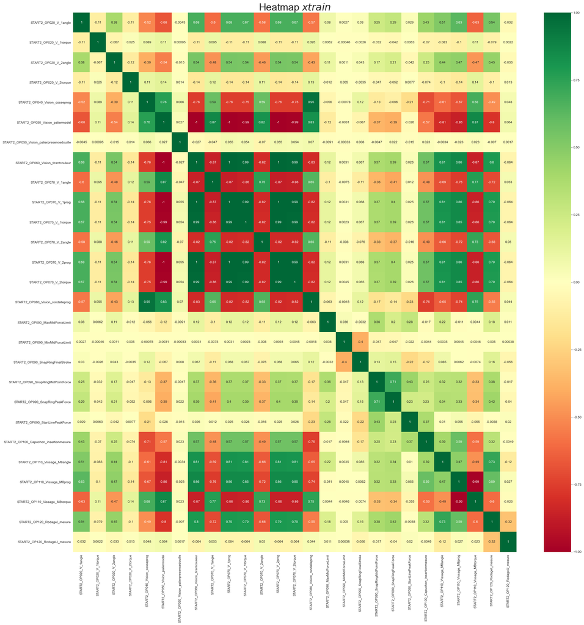

```python
# création et visualisation de la matrice de corrélation de xtrain
fig = plt.figure(figsize = (30, 30))
sns.heatmap(xtrain.corr(), annot = True, cmap = 'RdYlGn')
plt.title('Heatmap $xtrain$', fontsize = 30)
plt.show()
```

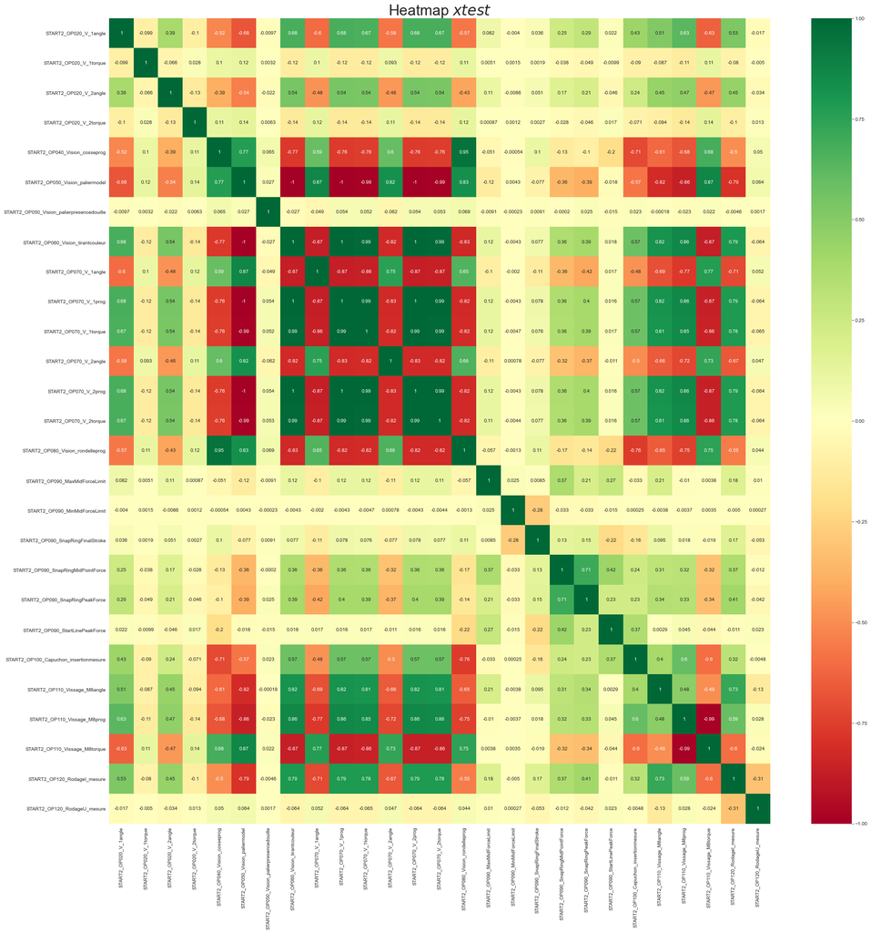

```python
# création et visualisation de la matrice de corrélation de xtest
fig = plt.figure(figsize = (30, 30))
sns.heatmap(xtest.corr(), annot = True, cmap = 'RdYlGn')
plt.title('Heatmap $xtest$', fontsize = 30)
plt.show()
```

> **Observations** : on observe que les relations entre les variables ne diffèrent pas significativement et semblent ainsi expliquer notre variable cible de la même manière.